# *Word Embeddings*

### *Plotting word2vec model*

```python
from sklearn.manifold import TSNE
import matplotlib.pyplot as plt
%matplotlib inline

def tsne_plot(model,search_words):
    "Creates and TSNE model and plots it"
    labels = []
    tokens = []

    similar_words = {search_term: [item[0] for item in model.wv.most_similar([search_term], topn=5)]
                  for search_term in search_words}
    words = sum([[k] + v for k, v in similar_words.items()], [])

    for word in words:
        tokens.append(model[word])
        labels.append(word)

    tsne_model = TSNE(n_components=2, init='pca', n_iter=250, random_state=23)
    new_values = tsne_model.fit_transform(tokens)

    x = []
    y = []
    for value in new_values:
        x.append(value[0])
        y.append(value[1])

    plt.figure(figsize=(8, 4))
    for i in range(len(x)):
        plt.scatter(x[i],y[i])
        plt.annotate(labels[i],
                     xy=(x[i], y[i]),
                     xytext=(5, 2),
                     textcoords='offset points',
                     ha='right',
                     va='bottom')
    plt.show()
```

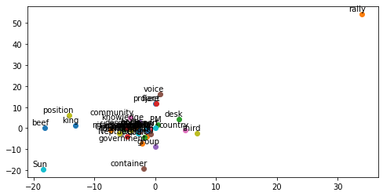

```python
tsne_plot(model, ['king', 'man','PM','wheat', 'knowledge', 'company','country'])
```

```python
import pandas as pd

words = model.wv.index2word
wvs = model.wv[words]

vec_df = pd.DataFrame(wvs, index=words)
vec_df
```

|  | 0 | 1 | 2 | 3 | 4 | 5 | 6 | 7 | 8 | 9 | 10 | 11 | 12 | 13 | 14 | 15 | 16 | 17 | 18 | 19 | 20 | 21 | 22 | 23 | 24 | 25 | 26 | 27 | 28 | … |
| --- | --- | --- | --- | --- | --- | --- | --- | --- | --- | --- | --- | --- | --- | --- | --- | --- | --- | --- | --- | --- | --- | --- | --- | --- | --- | --- | --- | --- | --- | --- |
| the | 1.180946 | -0.464140 | 0.466333 | 0.457773 | -0.849710 | 0.166648 | -0.954365 | -0.054045 | -0.620003 | 0.555244 | 0.036098 | -0.242980 | 1.988753 | -1.554386 | -0.993789 | -0.603275 | -0.626991 | 1.345692 | 0.919699 | 0.416056 | 0.495249 | -0.030729 | -0.226039 | -0.348821 | -0.667164 | 0.752879 | 0.229100 | 0.362967 | -0.596242 | … |
| . | 0.623628 | -0.027166 | 0.569407 | 0.746385 | 0.541308 | 0.407331 | 0.300251 | 1.713359 | -1.043029 | 1.151102 | -0.654210 | 0.562486 | -0.376537 | -0.089119 | -1.692528 | -0.928631 | -0.740152 | 1.543351 | 0.912655 | -0.613061 | -0.913171 | -0.237848 | -1.033536 | -0.060304 | -0.467906 | 0.088887 | 0.446462 | 1.006878 | -1.065560 | … |
| , | -0.326599 | 1.096351 | -1.680271 | -0.286190 | 0.250178 | 0.797010 | -1.124378 | 0.694572 | -0.330246 | 0.383416 | 0.029448 | 0.491414 | -0.726109 | -0.937306 | 0.738639 | 0.394603 | -0.616925 | 1.706009 | 0.289861 | 0.446539 | -0.902610 | -0.996444 | -1.514894 | -0.260623 | -0.219562 | 0.300556 | -0.148785 | 0.525263 | -0.070628 | … |
| of | -0.754485 | 1.026815 | 0.232551 | 0.362574 | 0.190551 | -0.392046 | -0.898486 | 1.202846 | -0.396003 | 0.918047 | -0.809964 | 0.120715 | 0.476474 | 0.140072 | 0.154465 | -1.534665 | -0.934079 | 0.460622 | -0.157869 | -0.489482 | -0.448073 | -0.181378 | -1.120321 | -0.082011 | -1.497689 | 0.668597 | -0.274785 | 1.868232 | -0.382035 | … |
| to | 0.288647 | 0.837984 | 0.928515 | -0.499792 | -0.426490 | 0.504831 | 1.327250 | 1.227047 | -2.114820 | 1.011656 | -1.168642 | 0.922873 | 1.499297 | 1.017401 | -0.006089 | 0.272431 | -2.641850 | 2.397187 | 0.374823 | -0.596449 | -0.495492 | -0.006277 | 0.548739 | 0.734193 | 0.882819 | -0.221134 | 2.232521 | 0.321092 | -1.378261 | … |
| ... | ... | ... | ... | ... | ... | ... | ... | ... | ... | ... | ... | ... | ... | ... | ... | ... | ... | ... | ... | ... | ... | ... | ... | ... | ... | ... | ... | ... | ... | … |
| dub | 0.000129 | 0.012912 | -0.002637 | 0.000477 | 0.010271 | 0.003473 | -0.012948 | 0.009872 | -0.003486 | 0.007195 | -0.003321 | -0.010862 | -0.002684 | -0.011640 | 0.001555 | 0.001304 | -0.001309 | -0.002815 | 0.003196 | -0.017986 | -0.006441 | 0.000199 | -0.023554 | 0.003720 | -0.002882 | 0.009029 | -0.008865 | 0.007863 | -0.008491 | … |
| lipid | 0.008871 | 0.012111 | 0.004673 | -0.005177 | -0.006914 | -0.003645 | -0.006536 | 0.007730 | -0.005732 | -0.004832 | -0.004969 | 0.008540 | -0.013770 | 0.004740 | 0.006399 | -0.005338 | -0.021860 | 0.015294 | -0.003246 | -0.011860 | -0.001611 | 0.003057 | -0.023184 | 0.012175 | 0.002473 | 0.004313 | 0.014094 | -0.005058 | -0.006869 | … |
| contaminant | -0.000586 | -0.002835 | 0.007773 | 0.002659 | 0.000893 | -0.007366 | -0.005671 | 0.008454 | 0.003937 | -0.004465 | -0.004187 | -0.002691 | 0.003539 | -0.004071 | 0.005543 | -0.003533 | 0.001121 | -0.001737 | 0.001680 | -0.009198 | 0.009572 | -0.000194 | 0.004524 | -0.014316 | -0.001768 | 0.000498 | 0.005969 | 0.002159 | -0.013031 | … |
| Scepticism | 0.009448 | -0.005282 | 0.000738 | -0.003108 | 0.008767 | 0.021857 | -0.010040 | -0.014628 | -0.011057 | -0.011102 | -0.004352 | 0.017030 | 0.001319 | 0.000212 | 0.016268 | 0.001806 | 0.005083 | 0.014838 | -0.001607 | -0.020826 | 0.005687 | -0.001074 | -0.014584 | -0.000226 | -0.001134 | 0.001855 | 0.014700 | 0.000034 | -0.001015 | … |
| astrobiologists | 0.016699 | -0.010088 | -0.003977 | -0.006382 | 0.001392 | 0.026384 | -0.007348 | -0.013202 | -0.018297 | -0.015821 | 0.004140 | 0.023301 | 0.007970 | 0.009909 | 0.013868 | -0.013346 | -0.003334 | 0.026629 | 0.000519 | -0.027735 | -0.006646 | 0.002639 | -0.028922 | 0.009500 | 0.003534 | 0.005740 | 0.017344 | -0.004881 | -0.010224 | … |

31885 rows × 100 columns

```python
## Looking at term semantic similarity

import numpy as np
from sklearn.metrics.pairwise import cosine_similarity

similarity_matrix = cosine_similarity(vec_df.values)
similarity_df = pd.DataFrame(similarity_matrix, index=words, columns=words)
similarity_df
```

|  | the | . | , | of | to | and | a | in | ' | is | says | " | that | s | for | The | - | are | it | be | have | ," | on | from | with | has | at | he | as | … |
| --- | --- | --- | --- | --- | --- | --- | --- | --- | --- | --- | --- | --- | --- | --- | --- | --- | --- | --- | --- | --- | --- | --- | --- | --- | --- | --- | --- | --- | --- | --- |
| the | 1.000000 | 0.438881 | 0.452163 | 0.477164 | 0.268495 | 0.361123 | 0.607784 | 0.515927 | 0.348143 | 0.257221 | 0.066442 | 0.317576 | 0.528171 | 0.313411 | 0.285149 | 0.671055 | 0.192669 | 0.131835 | 0.516389 | 0.230465 | 0.170394 | 0.151996 | 0.341054 | 0.166116 | 0.209529 | 0.096102 | 0.313855 | 0.288249 | 0.276285 | … |
| . | 0.438881 | 1.000000 | 0.408059 | 0.447017 | 0.332247 | 0.543079 | 0.327194 | 0.433638 | -0.015293 | 0.150354 | 0.135069 | -0.090161 | 0.313504 | 0.064565 | 0.456762 | 0.310323 | 0.298721 | 0.094659 | 0.137331 | 0.073295 | 0.052015 | 0.647107 | 0.419887 | 0.415716 | 0.427918 | 0.014473 | 0.303255 | 0.339631 | 0.331670 | … |
| , | 0.452163 | 0.408059 | 1.000000 | 0.434060 | 0.100649 | 0.431618 | 0.278965 | 0.440449 | 0.226138 | 0.278981 | 0.160037 | 0.108382 | 0.408774 | 0.141555 | 0.299179 | 0.253808 | 0.227666 | 0.327481 | 0.372141 | 0.251572 | 0.213076 | 0.392493 | 0.232002 | 0.476932 | 0.287580 | 0.090573 | 0.331204 | 0.151039 | 0.510296 | … |
| of | 0.477164 | 0.447017 | 0.434060 | 1.000000 | 0.150318 | 0.531236 | 0.355284 | 0.743308 | 0.167297 | 0.283842 | 0.019871 | 0.165725 | 0.352141 | 0.234827 | 0.448675 | 0.315780 | 0.432542 | 0.287087 | 0.200737 | 0.108588 | 0.062105 | 0.252058 | 0.547541 | 0.567782 | 0.445690 | -0.005741 | 0.640926 | 0.163936 | 0.459651 | … |
| to | 0.268495 | 0.332247 | 0.100649 | 0.150318 | 1.000000 | 0.453062 | 0.385790 | 0.308055 | 0.073308 | 0.187375 | -0.099812 | 0.234869 | 0.539585 | 0.013747 | 0.724858 | 0.278077 | 0.169020 | 0.165497 | 0.436494 | 0.236249 | 0.119455 | 0.105719 | 0.640354 | 0.069242 | 0.637417 | -0.037152 | 0.020627 | 0.279779 | 0.240026 | … |
| ... | ... | ... | ... | ... | ... | ... | ... | ... | ... | ... | ... | ... | ... | ... | ... | ... | ... | ... | ... | ... | ... | ... | ... | ... | ... | ... | ... | ... | ... | … |
| dub | 0.217049 | 0.488989 | 0.416897 | 0.272242 | -0.006475 | 0.296208 | 0.001954 | 0.256071 | 0.131371 | 0.152644 | 0.363966 | -0.106004 | 0.072728 | -0.074561 | 0.245338 | 0.266423 | 0.064108 | 0.283636 | 0.072985 | 0.140930 | 0.265079 | 0.429850 | 0.123466 | 0.468968 | 0.263312 | 0.194083 | 0.262829 | 0.278858 | 0.214461 | … |
| lipid | 0.231457 | 0.302624 | 0.242774 | 0.316350 | 0.396386 | 0.362590 | 0.453655 | 0.302938 | 0.077145 | 0.266143 | 0.125228 | 0.336968 | 0.281152 | 0.272589 | 0.464808 | 0.328388 | 0.549739 | 0.155934 | 0.200729 | 0.224765 | -0.000848 | 0.148624 | 0.491044 | 0.189907 | 0.354359 | 0.135641 | 0.172267 | 0.206644 | 0.279434 | … |
| contaminant | 0.240922 | 0.087994 | 0.065862 | 0.178203 | 0.222195 | -0.062039 | 0.253673 | 0.124609 | -0.201777 | 0.178838 | 0.053720 | 0.253834 | 0.349342 | 0.171917 | 0.194841 | 0.244906 | -0.023859 | -0.005052 | 0.449646 | 0.095242 | 0.113002 | 0.104159 | 0.128614 | -0.097807 | 0.121194 | 0.155481 | 0.079520 | 0.531234 | 0.130947 | … |
| Scepticism | 0.103878 | -0.090261 | 0.070050 | 0.018604 | 0.280980 | 0.102859 | 0.148032 | 0.088198 | 0.210242 | 0.304841 | 0.149330 | 0.414890 | 0.244063 | 0.178597 | 0.227338 | 0.351171 | 0.031880 | 0.248918 | 0.114584 | 0.091020 | 0.070211 | 0.006099 | 0.205051 | -0.015677 | 0.106168 | 0.221840 | 0.016845 | 0.073120 | 0.010855 | … |
| astrobiologists | 0.216877 | 0.113047 | 0.172273 | 0.143236 | 0.303390 | 0.310004 | 0.262461 | 0.185387 | 0.303502 | 0.295457 | 0.255594 | 0.381281 | 0.234979 | 0.253814 | 0.299333 | 0.376691 | 0.198622 | 0.246838 | 0.122439 | 0.064963 | -0.034138 | 0.102078 | 0.285140 | 0.153492 | 0.196386 | 0.141833 | 0.155075 | 0.108318 | 0.110576 | … |

31885 rows × 31885 columns

### *Loading Google word2vec*

```python
from gensim.models import KeyedVectors

# load the google word2vec model
filename = 'GoogleNews-vectors-negative300.bin'

model = KeyedVectors.load_word2vec_format(filename, binary=True)
# calculate: (king - man) + woman = ?

result = model.wv.most_similar(positive=['woman', 'king'], negative=['man'], topn=1)
print(result)
```

[output not shown]

*WORD EMBEDDING REPOSITORY: http://vectors.nlpl.eu/repository/*

#### *Gensim API*

```python
import gensim.downloader as api
word2vec_model = api.load('word2vec-google-news-300')
```

```
[=================================================-] 99.9% 1661.2/1662.8MB downloaded
```

```python
word2vec_model["beautiful"]
```

[output not shown]

### *SpaCy Models*

```python
!python -m spacy download en_core_web_md
```

```
✔ Download and installation successful
You can now load the model via spacy.load('en_core_web_md')
```

```python
import spacy
# Load the spacy model that you have installed
nlp = spacy.load('en_core_web_md')

# process a sentence using the model
doc = nlp("This is some text that I am processing with Spacy")
```

```python
# It's that simple - all of the vectors and words are assigned after this point
# Get the vector for 'text':
doc[3].vector
```

[output not shown]

```python
# Get the mean vector for the entire sentence (useful for sentence classification etc.)
doc.vector
```

[output not shown]

[output cut: 21 more lines]

```
        1.09824881e-01, -1.99228719e-01, -1.49215404e-02, -2.23988891e-01,
        1.06461301e-01,  7.05484003e-02,  6.54515028e-02, -1.27890497e-01,
        3.23300287e-02,  7.33296275e-02,  1.88077211e-01,  1.18194893e-01,
        8.73716325e-02, -7.22722933e-02,  5.59383444e-02,  6.47740066e-03,
        2.00715184e-01,  9.62314978e-02, -3.48809664e-03,  2.75218002e-02,
        2.66793407e-02, -4.74142991e-02, -6.72583003e-03,  6.16225004e-02,
        6.77095532e-01, -2.60432009e-02, -5.73220849e-02, -1.32674202e-01,
       -1.45575196e-01, -2.10457489e-01,  5.04911169e-02,  3.34890969e-02,
        1.69010018e-03,  7.47893304e-02,  1.15959838e-01,  1.70419499e-01,
        2.78796494e-01,  6.95598137e-04,  1.38465315e-01, -1.39558002e-01,
       -1.05340723e-02, -3.17818001e-02,  1.44083828e-01,  1.84036009e-02,
        7.65393823e-02, -1.08156681e-01, -1.86349601e-01, -1.51499901e-02,
       -2.16642022e-02, -4.31120396e-03,  8.77634883e-02, -6.35844022e-02,
       -1.29146904e-01, -2.63259001e-02, -1.46536082e-01,  2.72397280e-01],
      dtype=float32)
```

# *GloVe*

*The GloVe model stands for Global Vectors which is an unsupervised learning model which can be used to obtain dense word vectors similar to Word2Vec. However the technique is different and training is performed on an aggregated global word-word co-occurrence matrix, giving us a vector space with meaningful sub-structures.*

*The basic methodology of the GloVe model is to first create a huge word-context co-occurence matrix consisting of (word, context) pairs such that each element in this matrix represents how often a word occurs with the context (which can be a sequence of words). The idea then is to apply matrix factorization to approximate this matrix as depicted in the following figure.*

*Considering the Word-Context (WC) matrix, Word-Feature (WF) matrix and Feature-Context (FC) matrix, we try to factorize WC = WF x FC*

*Such that we we aim to reconstruct WC from WF and FC by multiplying them. For this, we typically initialize WF and FC with some random weights and attempt to multiply them to get WC' (an approximation of WC) and measure how close it is to WC. We do this multiple times using Stochastic Gradient Descent (SGD) to minimize the error. Finally, the Word-Feature matrix (WF) gives us the word embeddings for each word where F can be preset to a specific number of dimensions.*

#### *Co-occurrence Matrix*

*The co-occurrence matrix is also expressed by considering the relationship between words in the corpus.*

*For example, our corpus now includes the following three documents:*

*I like deep learning.*

*I like NLP.*

*I enjoy flying.*

*As an example, we set the window size to 1, which means that we only look at the word immediately surrounding a word. At this point, you will get a symmetric matrix-co-occurrence matrix. Because in our corpus, the number of times I and like appear as neighbors in the window at the same time is 2, the value where I and like intersect in the table below is 2.*

[figure not shown]

*In this way, the idea of turning words into vectors is done. Each row (or each column) of the co-occurrence matrix is a vector representation of the corresponding word.*

- *Although the Cocurrence matrix solves the relative position between words to some extent, this problem should be paid attention to. But it still faces dimensional disaster.*
- *In other words, the vector representation of a word is too long. At this time, it is natural to think of some common dimensionality reduction methods such as SVD or PCA.*

*The selection of the window size is the same as determining n in the n-gram. The size of the matrix will also increase when the window is enlarged, so it still has a large amount of calculation in nature, and the SVD algorithm has a large amount of calculation. If the text set is very More, it is not operable.*

### *Gensim*

```python
from gensim.scripts.glove2word2vec import glove2word2vec
from gensim.models import KeyedVectors

glove_input_file = 'glove.6B.100d.txt'
word2vec_output_file = 'glove.6B.100d.txt.word2vec'

_ = glove2word2vec(glove_input_file, word2vec_output_file)

model = KeyedVectors.load_word2vec_format(word2vec_output_file)
```

```python
model.similar_by_word('law')
```

```
[('laws', 0.8765358924865723),
 ('legal', 0.7683643102645874),
 ('rules', 0.74900221824646),
 ('constitutional', 0.7215015292167664),
 ('act', 0.7206457257270813),
 ('federal', 0.7192772626876831),
 ('legislation', 0.707940936088562),
 ('statute', 0.707027792930603),
 ('court', 0.7049846649169922),
 ('regulations', 0.6952557563781738)]
```

```python
model.doesnt_match('king man queen beer'.split())
```

```
'beer'
```

```python
model.similarity('man','woman')
```

```
0.8323494
```

### *Loading from text File*

```python
import numpy as np

glove_vectors = dict()

file = open('glove.6B.100d.txt', encoding = 'utf-8')

for line in file:
    values = line.split()
    word = values[0]
    vector = np.asarray(values[1:])
    glove_vectors[word] = vector

file.close()
```

```python
glove_vectors['random']
```

```
array(['-0.34378', '-0.13502', '-0.43921', '0.3171', '0.45931', '1.4118',
       '0.53641', '1.072', '-0.19217', '-0.19073', '-0.26035', '-0.16939',
       '0.11266', '-0.43995', '0.15545', '1.3412', '-0.34172', '0.94433',
       '0.062561', '0.63704', '0.5084', '-0.4696', '0.10751', '-0.21524',
       '0.50907', '-0.17371', '0.94811', '0.4571', '0.40394', '-0.12882',
       '0.50923', '-0.058139', '-0.55692', '-0.51644', '0.56536',
       '-0.28991', '-0.081733', '-0.1865', '0.67905', '-0.29877',
       '-0.17778', '0.42206', '-0.4408', '0.2316', '-0.95221', '0.22149',
       '-0.62444', '-0.14468', '-0.37559', '-0.4516', '1.1225',
       '-0.44304', '-0.17111', '0.058563', '0.44505', '-1.2974',
       '0.54388', '0.49319', '1.1714', '-0.20397', '0.18537', '0.11079',
       '0.011758', '0.33083', '1.4132', '-0.15832', '0.52176', '0.050126',
       '0.8741', '0.16155', '-0.99235', '-0.034789', '0.43111', '0.30439',
       '-0.0060538', '-0.10579', '0.13443', '-0.47229', '-1.179',
       '-0.025391', '0.97781', '0.18939', '-0.73967', '-0.2017',
       '-0.84043', '-0.017837', '0.64232', '-0.65417', '-0.64107',
       '0.27953', '-0.82348', '1.0642', '0.48362', '0.066701', '-0.26653',
       '0.099707', '0.2748', '-0.20851', '-0.26602', '0.058957'],
      dtype='<U10')
```

```python
# word_vector_matrix  = np.zeros(vocab_size, 200)
#
# for word, i in token.word_index.items():
#     vector = glove_vectors.get(word)
#     if vector is not None:
#         word_vector_matrix[i] = vector
#     else:
#         print(word)
```

### *spaCy*

```python
# import spacy
# language_model = spacy.load("en_core_web_lg")
#
# word_vectors = dict()
# for key, vector in language_model.vocab.vectors.items():
#     try:
#         word_string = language_model.vocab.strings[key]
#         word_vectors[word_string] = vector
#     except KeyError:
#         pass
```

```python
# doc = nlp(document_string)
#
# # Retrieve word vectors for each token.
# for token in doc:
#     print('Vector for %s:' % token, token.vector)
#
# # Compute word similarities using vector data.
# # We'll put these into a numpy matrix.
# matrix_rows = []
#
# for token1 in doc:
#     row = [token1.similarity(token2) for token2 in doc]
#     matrix_rows.append(row)
#
# similarity_matrix = np.array(matrix_rows)
```

```python
# tokens = nlp("dog cat banana afskfsd")
#
# for token in tokens:
#     print(token.text, token.has_vector, token.vector_norm, token.is_oov)

# for token1 in tokens:
#     for token2 in tokens:
#         print(token1.text, token2.text, token1.similarity(token2))
```

## *Training custom gloVe model*

`pip install glove_python`

```python
# from glove import Corpus, Glove
#
# #Creating a corpus object
# corpus = Corpus()
#
# #Training the corpus to generate the co occurence matrix which is used in GloVe
# corpus.fit(lines, window=10)
#
# glove = Glove(no_components=5, learning_rate=0.05)
# glove.fit(corpus.matrix, epochs=30, no_threads=4, verbose=True)
# glove.add_dictionary(corpus.dictionary)
# glove.save('glove.model')
```

# *FastText*

*FastText is a library created by the Facebook Research Team for efficient learning of word representations and sentence classification.*

*FastText differs in the sense that word vectors a.k.a word2vec treats every single word as the smallest unit whose vector representation is to be found but FastText assumes a word to be formed by a n-grams of character, for example, sunny is composed of [sun, sunn,sunny],[sunny,unny,nny] etc, where n could range from 1 to the length of the word. This new representation of word by fastText provides the following benefits over word2vec or glove.*

- *It is helpful to find the vector representation for rare words. Since rare words could still be broken into character n-grams, they could share these n-grams with the common words. For example, for a model trained on a news dataset, the medical terms eg: diseases can be the rare words.*
- *It can give the vector representations for the words not present in the dictionary (OOV words) since these can also be broken down into character n-grams. word2vec and glove both fail to provide any vector representations for words not in the dictionary.*

*For example, for a word like stupedofantabulouslyfantastic, which might never have been in any corpus, gensim might return any two of the following solutions – a) a zero vector or b) a random vector with low magnitude. But FastText can produce vectors better than random by breaking the above word in chunks and using the vectors for those chunks to create a final vector for the word. In this particular case, the final vector might be closer to the vectors of fantastic and fantabulous.*

- *Character n-grams embeddings tend to perform superior to word2vec and glove on smaller datasets.*

### *Gensim*

```python
# from gensim.models.fasttext import FastText
#
# # Set values for various parameters
# feature_size = 15    # Word vector dimensionality
# window_context = 20  # Context window size
# min_word_count = 1   # Minimum word count
# sample = 1e-3        # Downsample setting for frequent words
# sg = 1               # skip-gram model
#
# ft_model = FastText(tokenized_corpus, size=feature_size,
#                      window=window_context, min_count = min_word_count,
#                      sg=sg, sample=sample, iter=5000)
# ft_model
```

```python
# Pretrained Models

# model = FastText.load_fasttext_format('wiki-news-300d-1M-subword.bin')
```

### *FastText*

```python
# import fasttext
#
# # Skipgram model :
# model = fasttext.train_unsupervised('data.txt', model='skipgram')
#
# # or, cbow model :
# model = fasttext.train_unsupervised('data.txt', model='cbow')

# model.save_model("model_filename.bin")

# model = fasttext.load_model("model_filename.bin")
```

### *GluonNLP*

```python
#fasttext = gluonnlp.embedding.create('fasttext', source='wiki.simple')
#fasttext[word].asnumpy()
#
#glove = gluonnlp.embedding.create('glove', source='glove.6B.300d')
#glove[word].asnumpy()
```

*[FastText Reference](https://stackabuse.com/python-for-nlp-working-with-facebook-fasttext-library/)*

## *Embeddings in Keras*

### *One-Hot Encoding*

#### *Why is it called One-Hot?*

*After each word is one-hot encoded, only one position has an element of 1 and the other positions are all 0.*

*For example, the sentence **"the boy is crying"** (assuming there are only four English words in the world), after one-hot encoding,*

- *the corresponds to (1, 0, 0, 0)*
- *boy corresponds to (0, 1, 0, 0)*
- *is corresponds to (0,0,1,0)*
- *crying corresponds to (0,0,0,1)*

*Each word corresponds to a position in the vector, and this position represents the word.*

*But this way requires a very high dimension, because if all vocabularies have 100,000 words, then each word needs to be represented by a vector of length 100,000.*

- *the corresponding to (1, 0, 0, 0, ..., 0) (length is 100,000)*
- *boy corresponding to (0, 1, 0, 0, ..., 0)*
- *is corresponding to (0, 0, 1, 0 , ..., 0)*
- *crying corresponds to (0,0,0,1, ..., 0) to get high-dimensional sparse tensors.*

#### *Disadvatages of One-Hot Encoding*

*One-Hot coding is simple and easy to use, the disadvantages are also obvious:*

- *The length of the word vector is equal to the length of the vocabulary, and the word vector is extremely sparse. When the vocabulary is large, the computational complexity will be very large.*
- *Any two words are orthogonal, meaning that the relationship between words cannot be obtained from the One-Hot code.*
- *The distance between any two words is equal, and the semantic relevance of the two words cannot be reflected from the distance.*

### *Embedding in Keras*

*In contrast, word embedding embeds words into a low-dimensional dense space.*

*For example, the same "the boy is crying" sentence (assuming that there are only 4 English words in the world), after encoding, it may become:*

- *the corresponding (0.1)*
- *boy corresponding (0.14)*
- *is corresponding (0)*
- *crying corresponding (0.82)*

*We assume that the embedded space is 256 dimensions (generally 256, 512 or 1024 dimensions, the larger the vocabulary, the higher the corresponding spatial dimension).*

*One-hot encoding is very simple, but the spatial dimension is high and for one-hot encoding, the distance between any two words is √2*

*But in practice, the word (boy) to word (man) should be very close (because they are closely related), and the word (cat) to word (stone) should be very far (because they are basically unrelated).*

*Embedding space has low dimensions and allows space to have structure.*

*For example, the distance between the vectors can reflect gender, age, etc. (this requires training, and the unembedding layer has no structure), for example:*

- *man-woman = boy-girl*
- *man-daddy = woman-mother*

*To implement word embeddings, the Keras library contains a layer called **Embedding()**. The embedding layer is implemented in the form of a class in Keras and is normally used as a first layer in the sequential model for NLP tasks.*

*The embedding layer can be used to peform three tasks in Keras:*

- *It can be used to learn word embeddings and save the resulting model.*
- *It can be used to learn the word embeddings in addition to performing the NLP tasks such as text classification, sentiment analysis, etc.*
- *It can be used to load pretrained word embeddings and use them in a new model.*

*Let's see how the embedding layer looks:*

```
embedding_layer = Embedding(200, 32, input_length=50)
```

*The first parameter in the embeddig layer is the size of the vocabulary or the total number of unique words in a corpus. The second parameter is the number of the dimensions for each word vector. For instance, if you want each word vector to have 32 dimensions, you will specify 32 as the second parameter. And finally, the third parameter is the length of the input sentence.*

*The output of the word embedding is a 2D vector where words are represented in rows, whereas their corresponding dimensions are presented in columns. Finally, if you wish to directly connect your word embedding layer with a densely connected layer, you first have to flatten your 2D word embeddings into 1D. These concepts will become more understandable once we see word embedding in action.*

#### *Custom Word Embeddings*

```python
from numpy import array
from keras.preprocessing.text import one_hot
from keras.preprocessing.sequence import pad_sequences
from keras.models import Sequential
from keras.layers import Dense
from keras.layers import Flatten
from keras.layers.embeddings import Embedding
```

```python
corpus = [
    # Positive Reviews

    'This is an excellent movie',
    'The move was fantastic I like it',
    'You should watch it is brilliant',
    'Exceptionally good',
    'Wonderfully directed and executed I like it',
    'Its a fantastic series',
    'Never watched such a brillent movie',
    'It is a Wonderful movie',

    # Negtive Reviews

    "horrible acting",
    'waste of money',
    'pathetic picture',
    'It was very boring',
    'I did not like the movie',
    'The movie was horrible',
    'I will not recommend',
    'The acting is pathetic'
]
```

```python
sentiments = array([1,1,1,1,1,1,1,1,0,0,0,0,0,0,0,0])
```

```python
from nltk.tokenize import word_tokenize

all_words = []
for sent in corpus:
    tokenize_word = word_tokenize(sent)
    for word in tokenize_word:
        all_words.append(word)
```

```python
unique_words = set(all_words)
print(len(unique_words))
```

```
45
```

_The Embedding layer expects the words to be in numeric form. Therefore, we need to convert the sentences in our corpus to numbers. One way to convert text to numbers is by using the one*hot function from the keras.preprocessing.text library. The function takes sentence and the total length of the vocabulary and returns the sentence in numeric form.*

```python
vocab_length=50
embedded_sentences = [one_hot(sent, vocab_length) for sent in corpus]
print(embedded_sentences )
```

```
[[44, 6, 19, 7, 29], [1, 13, 16, 21, 6, 38, 27], [5, 47, 17, 27, 6, 34], [31, 34], [4, 47, 20, 15, 6, 38, 27], [26, 42, 21, 33], [8, 38, 26, 42, 34, 29], [27, 6, 42, 31, 29], [49, 27], [16, 28, 47], [40, 11], [27, 16, 15, 42], [6, 46, 40, 38, 1, 29], [1, 29, 16, 49], [6, 4, 40, 44], [1, 27, 6, 40]]
```

```python
word_count = lambda sentence: len(word_tokenize(sentence))
longest_sentence = max(corpus, key=word_count)
length_long_sentence = len(word_tokenize(longest_sentence))
```

```python
padded_sentences = pad_sequences(embedded_sentences, length_long_sentence, padding='post')
print(padded_sentences)
```

```
[[44  6 19  7 29  0  0]
 [ 1 13 16 21  6 38 27]
 [ 5 47 17 27  6 34  0]
 [31 34  0  0  0  0  0]
 [ 4 47 20 15  6 38 27]
 [26 42 21 33  0  0  0]
 [ 8 38 26 42 34 29  0]
 [27  6 42 31 29  0  0]
 [49 27  0  0  0  0  0]
 [16 28 47  0  0  0  0]
 [40 11  0  0  0  0  0]
 [27 16 15 42  0  0  0]
 [ 6 46 40 38  1 29  0]
 [ 1 29 16 49  0  0  0]
 [ 6  4 40 44  0  0  0]
 [ 1 27  6 40  0  0  0]]
```

```python
model = Sequential()
model.add(Embedding(vocab_length, 20, input_length=length_long_sentence))
model.add(Flatten())
model.add(Dense(1, activation='sigmoid'))
```

```python
model.compile(optimizer='adam', loss='binary_crossentropy', metrics=['acc'])
print(model.summary())
```

```
Model: "sequential"
_________________________________________________________________
Layer (type)                 Output Shape              Param #
=================================================================
embedding (Embedding)        (None, 7, 20)             1000
_________________________________________________________________
flatten (Flatten)            (None, 140)               0
_________________________________________________________________
dense (Dense)                (None, 1)                 141
=================================================================
Total params: 1,141
Trainable params: 1,141
Non-trainable params: 0
_________________________________________________________________
None
```

```python
model.fit(padded_sentences, sentiments, epochs=100, verbose=1)
```

```
<tensorflow.python.keras.callbacks.History at 0x7fc39572f7b8>
```

```python
loss, accuracy = model.evaluate(padded_sentences, sentiments, verbose=0)
print('Accuracy: %f' % (accuracy*100))
```

```
Accuracy: 100.000000
```

#### *Loading Pretrained Word Embeddings*

```python
from keras.preprocessing.text import Tokenizer
word_tokenizer = Tokenizer()
word_tokenizer.fit_on_texts(corpus)
```

```python
vocab_length = len(word_tokenizer.word_index) + 1
```

```python
embedded_sentences = word_tokenizer.texts_to_sequences(corpus)
print(embedded_sentences)
```

```
[[14, 3, 15, 16, 1], [4, 17, 6, 9, 5, 7, 2], [18, 19, 20, 2, 3, 21], [22, 23], [24, 25, 26, 27, 5, 7, 2], [28, 8, 9, 29], [30, 31, 32, 8, 33, 1], [2, 3, 8, 34, 1], [10, 11], [35, 36, 37], [12, 38], [2, 6, 39, 40], [5, 41, 13, 7, 4, 1], [4, 1, 6, 10], [5, 42, 13, 43], [4, 11, 3, 12]]
```

```python
from nltk.tokenize import word_tokenize

word_count = lambda sentence: len(word_tokenize(sentence))
longest_sentence = max(corpus, key=word_count)
length_long_sentence = len(word_tokenize(longest_sentence))

padded_sentences = pad_sequences(embedded_sentences, length_long_sentence, padding='post')

print(padded_sentences)
```

```
[[14  3 15 16  1  0  0]
 [ 4 17  6  9  5  7  2]
 [18 19 20  2  3 21  0]
 [22 23  0  0  0  0  0]
 [24 25 26 27  5  7  2]
 [28  8  9 29  0  0  0]
 [30 31 32  8 33  1  0]
 [ 2  3  8 34  1  0  0]
 [10 11  0  0  0  0  0]
 [35 36 37  0  0  0  0]
 [12 38  0  0  0  0  0]
 [ 2  6 39 40  0  0  0]
 [ 5 41 13  7  4  1  0]
 [ 4  1  6 10  0  0  0]
 [ 5 42 13 43  0  0  0]
 [ 4 11  3 12  0  0  0]]
```

```python
!wget http://nlp.stanford.edu/data/glove.6B.zip
```

[output not shown]

```python
!unzip glove*.zip
```

```
Archive:  glove.6B.zip
  inflating: glove.6B.50d.txt
  inflating: glove.6B.100d.txt
  inflating: glove.6B.200d.txt
  inflating: glove.6B.300d.txt
```

```python
from numpy import array
from numpy import asarray
from numpy import zeros

embeddings_dictionary = dict()
glove_file = open('/content/glove.6B.100d.txt', encoding="utf8")
```

```python
for line in glove_file:
    records = line.split()
    word = records[0]
    vector_dimensions = asarray(records[1:], dtype='float32')
    embeddings_dictionary [word] = vector_dimensions

glove_file.close()
```

```python
embedding_matrix = zeros((vocab_length, 100))
for word, index in word_tokenizer.word_index.items():
    embedding_vector = embeddings_dictionary.get(word)
    if embedding_vector is not None:
        embedding_matrix[index] = embedding_vector
```

```python
model = Sequential()
embedding_layer = Embedding(vocab_length, 100, weights=[embedding_matrix], input_length=length_long_sentence, trainable=False)
model.add(embedding_layer)
model.add(Flatten())
model.add(Dense(1, activation='sigmoid'))
```

```python
model.compile(optimizer='adam', loss='binary_crossentropy', metrics=['acc'])
print(model.summary())
```

```
Model: "sequential_1"
_________________________________________________________________
Layer (type)                 Output Shape              Param #
=================================================================
embedding_1 (Embedding)      (None, 7, 100)            4400
_________________________________________________________________
flatten_1 (Flatten)          (None, 700)               0
_________________________________________________________________
dense_1 (Dense)              (None, 1)                 701
=================================================================
Total params: 5,101
Trainable params: 701
Non-trainable params: 4,400
_________________________________________________________________
None
```

```python
model.fit(padded_sentences, sentiments, epochs=100, verbose=1)
```

```
<tensorflow.python.keras.callbacks.History at 0x7fc38eaf6b38>
```

```python
loss, accuracy = model.evaluate(padded_sentences, sentiments, verbose=0)
print('Accuracy: %f' % (accuracy*100))
```

```
Accuracy: 100.000000
```

### *Common Errors*

- *You need to use the exact same pipeline during deploying your model as were used to create the training data for the word embedding. If you use a different tokenizer or different method of handling white space, punctuation etc. you might end up with incompatible inputs.*
- *Words in your input that doesn’t have a pre-trained vector. Such words are known as Out of Vocabulary Word(oov). What you can do is replace those words with “UNK” which means unknown and then handle them separately.*
- *Dimension mis-match: Vectors can be of many lengths. If you train a model with vectors of length say 400 and then try to apply vectors of length 1000 at inference time, you will run into errors. So make sure to use the same dimensions throughout.*

### *Benefits of using Word Embeddings*

- *It is much faster to train than hand build models like WordNet(which uses graph embeddings)*
- *Almost all modern NLP applications start with an embedding layer*
- *It Stores an approximation of meaning*

### *Drawbacks of Word Embeddings*

- *It can be memory intensive*
- *It is corpus dependent. Any underlying bias will have an effect on your model*
- *It cannot distinguish between homophones. Eg: brake/break, cell/sell, weather/whether etc.*